# Vector data analysis in R

Author

Krzysztof Dyba

```r
# load the package
library("terra")

# prevent scientific notation
options(scipen = 8)
```

# Introduction

In the `data` folder, there are two vector files with the `.gpkg` extension (*geopackage*). They represent the districts of Warsaw and parks as polygon objects. The data were downloaded from [OpenStreetMap](https://www.openstreetmap.org/) using the osmdata package. The purpose of this analysis is to identify the accessibility of parks in the urban environment.

Let’s start by loading these two files (`districts.gpkg` and `parks.gpkg`) using the `vect()` function. We must specify the paths to these files in the function.

```r
# load vector layer
districts = vect("data/districts.gpkg")
districts
```

```
class       : SpatVector
geometry    : polygons
dimensions  : 18, 1  (geometries, attributes)
extent      : 20.85169, 21.27115, 52.09785, 52.36815  (xmin, xmax, ymin, ymax)
source      : districts.gpkg
coord. ref. : lon/lat WGS 84 (EPSG:4326)
names       :    name
type        :   <chr>
values      :  Bemowo
              Bielany
                 Wola
              ...
```

We can access the `name` attribute using the dollar sign (`districts$name`), which returns a vector, or using double square brackets (`districts[["name"]]`), which returns a data frame.

```r
# names of districts in Warsaw
districts$name
```

```
 [1] "Bemowo"         "Bielany"        "Wola"           "Żoliborz"
 [5] "Ochota"         "Ursus"          "Włochy"         "Śródmieście"
 [9] "Mokotów"        "Ursynów"        "Wilanów"        "Praga-Południe"
[13] "Praga-Północ"   "Białołęka"      "Targówek"       "Rembertów"
[17] "Wawer"          "Wesoła"
```

Now let’s load the parks.

```r
# load vector layer
parks = vect("data/parks.gpkg")
parks
```

```
class       : SpatVector
geometry    : polygons
dimensions  : 481, 2  (geometries, attributes)
extent      : 20.85633, 21.27411, 52.09667, 52.36187  (xmin, xmax, ymin, ymax)
source      : parks.gpkg
coord. ref. : lon/lat WGS 84 (EPSG:4326)
names       :  osm_id                          name
type        :   <chr>                         <chr>
values      : 4943389                  Ogród Saski
              4999161 Skwer Antoniego Słonimskiego
              5000672          Park Szczęśliwicki
              ...
```

After loading vector data, it is good practice to check that the geometry is valid. The `is.valid()` function is designed for this purpose. If a layer consists of multiple objects, it is advisable to use the additional `all()` function, which returns whether the geometries of all objects are valid. If the geometry is invalid, you can try to fix it using the `makeValid()` function, although this does not always work.

```r
# check geometry validity
all(is.valid(districts))
```

```
[1] TRUE
```

```r
all(is.valid(parks))
```

```
[1] TRUE
```

For simple visualizations, we can use the `plot()` function. If we want to overlay several layers, we must use the `add = TRUE` argument. The first layer is displayed as the base layer, and subsequent layers are added on top of it.

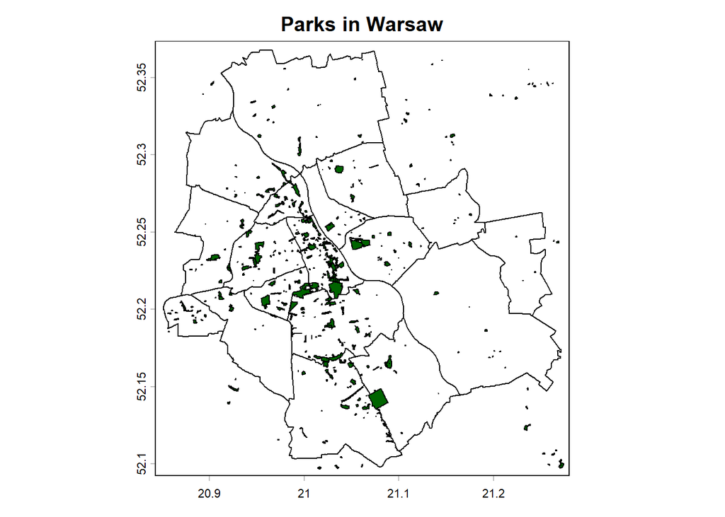

```r
plot(districts, main = "Parks in Warsaw")
plot(parks, add = TRUE, col = "darkgreen")
```

The `parks` object contains some park names. Let’s check how many parks have no name (`NA`). We can check for missing values using the `is.na()` function on the `name` attribute. Then, we can count the occurrences using the `table()` function.

```r
# is park name missing?
table(is.na(parks$name))
```

```
FALSE  TRUE
  262   219
```

# Vector Operations

## Polygon Statistics

Let’s calculate the area and perimeter of polygons. The `expanse()` function is for calculating area, while the `perim()` function is for calculating perimeter. For area, we can specify the unit of the result (the `unit` argument).

```r
# calculate the area
parks$area_m2 = expanse(parks, unit = "m")
summary(parks$area_m2)
```

```
      Min.    1st Qu.     Median       Mean    3rd Qu.       Max.
     34.36    2424.41    6200.97   27505.44   21811.87 1153776.90
```

```r
# calculate the perimeter
parks$perim_m = perim(parks)
summary(parks$perim_m)
```

```
   Min. 1st Qu.  Median    Mean 3rd Qu.    Max.
  23.45  231.76  400.32  644.09  757.29 5950.04
```

Now that we have the results, we can sort the objects from largest to smallest area. Objects of the `SpatVector` class behave similarly to data frames, so we can use the `order()` function to sort them.

```r
# sort by area
largest_parks = parks[order(parks$area_m2, decreasing = TRUE), ]
```

We can display the results as a classic data frame after converting them using `as.data.frame()` function.

```r
# convert SpatVector to data frame
largest_parks = as.data.frame(largest_parks)
head(largest_parks)
```

```
     osm_id               name   area_m2  perim_m
1  96580361    Park Natoliński 1153776.9 4580.138
2  25748408               <NA>  715017.3 4264.739
3 131355906               <NA>  587877.3 5440.940
4 217142429               <NA>  422029.0 3904.727
5   5000672 Park Szczęśliwicki  356653.0 2715.469
6  23518638  Dolinka Służewska  333662.6 4216.425
```

In the following part of the analysis, let’s exclude small parks with an area of less than 2,000 $m^2$. We need to use square brackets with the appropriate condition on the `area_m2` attribute.

```r
# data filtering
parks_clean = parks[parks$area_m2 > 2000, ]
```

## Spatial Relationships

Based on the map, we can conclude that the spatial distribution of parks is not uniform and that some parks are located outside the administrative boundaries of Warsaw. Spatial relationships define how objects are related to each other in terms of location, distance, and interaction in space.

So let’s check which parks are located in specific districts. To do this, we need to use the `relate()` function, which will check the selected relationship between all objects. The result will be a matrix of logical values. The relationship we are interested in is `intersects`.

```r
# check if objects intersect
intersect_mat = relate(districts, parks_clean, relation = "intersects")
# View(intersect_mat)
```

Next, for each district, we can count the total number of parks. The districts are defined in rows, so we need to use the `rowSums()` function.

```r
# count parks by districts
district_stats = data.frame(name = districts$name, count = rowSums(intersect_mat))
head(district_stats)
```

```
      name count
1   Bemowo    11
2  Bielany    12
3     Wola    31
4 Żoliborz    23
5   Ochota    20
6    Ursus    16
```

Note that parks intersecting each district are counted. If a park is located in two districts, it will be included in both.

## Availability Analysis

Let’s now assess the accessibility of parks. We can consider two scenarios:

1. Parks with good accessibility within 300 m (average walking time ~4 minutes).
2. Parks with moderate accessibility within 1000 m (average walking time ~15 minutes).

To perform this analysis, we need to use buffers. A buffer is a zone of a specified width created around a selected geographic feature (point, line, or polygon). This allows us to determine what lies within a specified range of the location of interest. However, this distance is measured in a straight line (it does not show the real walking distance along the street network). To create the buffer, we will use the `buffer()` function and specify the range in meters (the `width` argument).

```r
# generate buffers
buffers_300 = buffer(parks_clean, width = 300)
buffers_1000 = buffer(parks_clean, width = 1000)
```

We get 383 buffers (the same number as the number of input objects). These buffers largely overlap. Therefore, we can dissolve them into a single (multi)polygon using the `aggregate()` function.

```r
# combine overlapping geometries
buffers_300 = aggregate(buffers_300)
buffers_1000 = aggregate(buffers_1000)
```

Some of the parks and their buffers extend beyond the city boundaries. We can clip them exactly to the city boundaries using the `crop()` function.

```r
# clip buffers to the city boundary
buffers_300 = crop(buffers_300, districts)
buffers_1000 = crop(buffers_1000, districts)
```

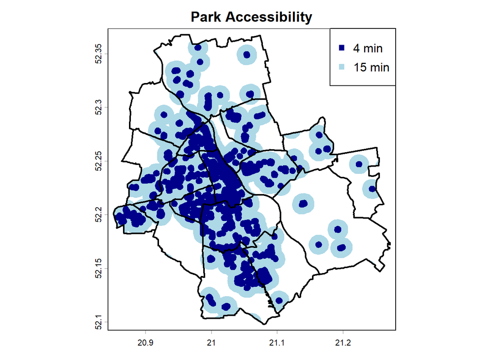

```r
plot(districts, main = "Park Accessibility", border = NA, legend = FALSE)
plot(buffers_1000, col = "lightblue", border = NA, add = TRUE)
plot(buffers_300, col = "darkblue", border = NA, add = TRUE)
plot(districts, lwd = 2, add = TRUE)
add_legend("topright", legend = c("4 min", "15 min"), pch = 15,
           col = c("darkblue", "lightblue"))
```

We can calculate the total area covered by these buffers and the ratio to the area of the entire city as a percentage.

```r
# the total area of the city
city_area = sum(expanse(districts))

# buffer area
coverage_stats = data.frame(
  threshold = c("300 m", "1000 m"),
  covered_area_m2 = c(expanse(buffers_300), expanse(buffers_1000))
)
coverage_stats$pct_covered = coverage_stats$covered_area_m2 / city_area * 100

coverage_stats
```

```
  threshold covered_area_m2 pct_covered
1     300 m       111548628    21.56820
2    1000 m       295207261    57.07905
```

We can also identify the areas where access to parks is more difficult (distances greater than 1,000 m). We can do this by subtracting two vector layers using the `erase()` function.

```r
# vector layers difference
bad_access = erase(aggregate(districts), buffers_1000)
```

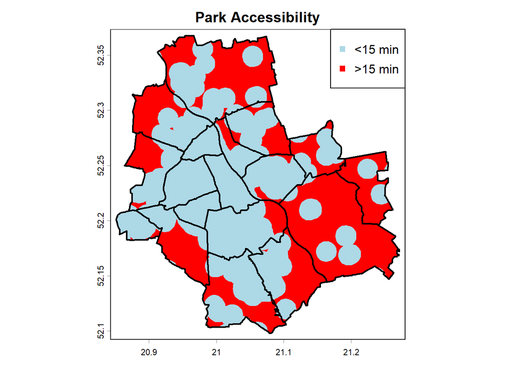

```r
plot(districts, main = "Park Accessibility", col = "lightblue", border = NA,
     legend = FALSE)
plot(bad_access, col = "red", border = NA, add = TRUE)
plot(districts, lwd = 2, add = TRUE)
add_legend("topright", legend = c("<15 min", ">15 min"), pch = 15,
           col = c("lightblue", "red"))
```

## Proximity Analysis

Finally, let’s find the nearest park located next to our faculty. The coordinates of our faculty are $X = 21.007$ (longitude) and $Y = 52.222$ (latitude) in the geographic coordinate system (`EPSG:4326`).

Let’s create a point that represents these geographic coordinates. The simplest way is to create a matrix with two columns. The first column will represent longitude, and the second will represent latitude. Next, pass the matrix to the `vect()` function and define the coordinate system in the `crs` argument.

```r
# create point (SpatVector) from coordinates
pt = cbind(21.007, 52.222)
pt = vect(pt, crs = "EPSG:4326")
```

To find the nearest park, we will use the `nearby()` function, which searches for `k` nearest neighbors (default 1). The result is a matrix containing the indices of the nearest objects.

```r
# find the nearest park
idx = nearby(pt, parks_clean, centroids = FALSE)
idx = idx[, 2]
```

Next, using the `distance()` function, we can calculate the distance between the faculty and this park. By default, the distance is returned in meters.

```r
# calculate distance
distance(pt, parks_clean[idx, ], unit = "m")
```

```
         [,1]
[1,] 411.5646
```

The distance between the faculty and the nearest park is ~411 meters.

In the `nearby()` function, you may have noticed that we used the `centroids` argument set to `FALSE`. By default, it is set to `TRUE`, which means that the centroid will be used to calculate distances for polygons. A centroid is the geometric center of a spatial object, represented as a single point. Therefore, the difference in distance to the boundary of the polygon and to its centroid will be different. In our examples, we calculated the distance to the polygon boundary.

The `centroids()` function is used to calculate centroids. Let’s find out where the centroid of the selected park is located.

```r
# calculate centroids
cent = centroids(parks_clean[idx, ])
```

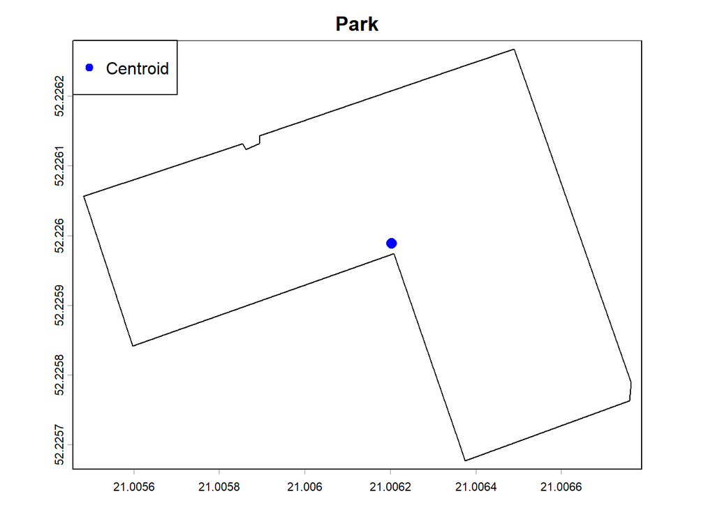

```r
plot(parks_clean[idx, ], main = "Park", legend = FALSE)
plot(cent, add = TRUE, col = "blue", cex = 1.4)
add_legend("topleft", legend = "Centroid", pch = 19, col = "blue")
```

We can determine the coordinates of spatial objects (including points) using the `crds()` function.

```r
# centroid coordinates
crds(cent)
```

```
           x        y
[1,] 21.0062 52.22599
```

## Reproject

We can transform (reproject) the coordinate system using the `project()` function. Simply specify the target coordinate system, preferably by providing the EPSG code. A list of codes for specific areas based on the map can be found on the [CRS Explorer](https://crs-explorer.proj.org/) website. In our example, we will use the *Polish National Geodetic Coordinate System 1992* as the target coordinate system, whose code is `EPSG:2180`.

```r
# reproject CRS
buffers_300_epsg2180 = project(buffers_300, "EPSG:2180")
```

After the above transformation, the coordinates are now expressed in meters (they were previously in degrees).

## Exporting Results

Let’s export the results to a vector file to disk. The most common format is geopackage (`.gpkg`). The `writeVector()` function is needed to save the data.

```r
# save buffers to disk
writeVector(buffers_300, "buffers_300.gpkg")
```

# Exercise

1. For each district, calculate its centroid. Then, for each centroid, find the nearest park and calculate the pairwise distances. To the layer with districts, add a column containing the name of the nearest park and the distance to it. Save the result to disk as a geopackage.